# Risk Factor Analysis

## Outcome Variable

**Outcome Variable:** wasted

## Predictor Variables

**Intervention Variable:** birthwt

**Adjustment Set:**

unadjusted

## Stratifying Variables

The analysis was stratified on these variable(s):

- agecat
- studyid
- country

## Data Summary

| agecat | studyid | country | birthwt | wasted | n_cell | n |
| --- | --- | --- | --- | --- | --- | --- |
| Birth | CMC-V-BCS-2002 | INDIA | Normal or high birthweight | 0 | 71 | 86 |
| Birth | CMC-V-BCS-2002 | INDIA | Normal or high birthweight | 1 | 5 | 86 |
| Birth | CMC-V-BCS-2002 | INDIA | Low birthweight | 0 | 4 | 86 |
| Birth | CMC-V-BCS-2002 | INDIA | Low birthweight | 1 | 6 | 86 |
| Birth | CMIN | BANGLADESH | Normal or high birthweight | 0 | 13 | 19 |
| Birth | CMIN | BANGLADESH | Normal or high birthweight | 1 | 1 | 19 |
| Birth | CMIN | BANGLADESH | Low birthweight | 0 | 2 | 19 |
| Birth | CMIN | BANGLADESH | Low birthweight | 1 | 3 | 19 |
| Birth | COHORTS | GUATEMALA | Normal or high birthweight | 0 | 540 | 756 |
| Birth | COHORTS | GUATEMALA | Normal or high birthweight | 1 | 162 | 756 |
| Birth | COHORTS | GUATEMALA | Low birthweight | 0 | 24 | 756 |
| Birth | COHORTS | GUATEMALA | Low birthweight | 1 | 30 | 756 |
| Birth | COHORTS | INDIA | Normal or high birthweight | 0 | 4632 | 6193 |
| Birth | COHORTS | INDIA | Normal or high birthweight | 1 | 546 | 6193 |
| Birth | COHORTS | INDIA | Low birthweight | 0 | 465 | 6193 |
| Birth | COHORTS | INDIA | Low birthweight | 1 | 550 | 6193 |
| Birth | COHORTS | PHILIPPINES | Normal or high birthweight | 0 | 2371 | 2899 |
| Birth | COHORTS | PHILIPPINES | Normal or high birthweight | 1 | 317 | 2899 |
| Birth | COHORTS | PHILIPPINES | Low birthweight | 0 | 77 | 2899 |
| Birth | COHORTS | PHILIPPINES | Low birthweight | 1 | 134 | 2899 |
| Birth | CONTENT | PERU | Normal or high birthweight | 0 | 2 | 2 |
| Birth | CONTENT | PERU | Normal or high birthweight | 1 | 0 | 2 |
| Birth | CONTENT | PERU | Low birthweight | 0 | 0 | 2 |
| Birth | CONTENT | PERU | Low birthweight | 1 | 0 | 2 |
| Birth | EE | PAKISTAN | Normal or high birthweight | 0 | 127 | 177 |
| Birth | EE | PAKISTAN | Normal or high birthweight | 1 | 11 | 177 |
| Birth | EE | PAKISTAN | Low birthweight | 0 | 28 | 177 |
| Birth | EE | PAKISTAN | Low birthweight | 1 | 11 | 177 |
| Birth | GMS-Nepal | NEPAL | Normal or high birthweight | 0 | 423 | 641 |
| Birth | GMS-Nepal | NEPAL | Normal or high birthweight | 1 | 49 | 641 |

[output cut: 258 more lines]

The following strata were considered:

- agecat: 24 months, studyid: CMC-V-BCS-2002, country: INDIA
- agecat: 24 months, studyid: CMIN, country: BANGLADESH
- agecat: 24 months, studyid: COHORTS, country: GUATEMALA
- agecat: 24 months, studyid: COHORTS, country: INDIA
- agecat: 24 months, studyid: COHORTS, country: PHILIPPINES
- agecat: 24 months, studyid: CONTENT, country: PERU
- agecat: 24 months, studyid: EE, country: PAKISTAN
- agecat: 24 months, studyid: GMS-Nepal, country: NEPAL
- agecat: 24 months, studyid: IRC, country: INDIA
- agecat: 24 months, studyid: Keneba, country: GAMBIA
- agecat: 24 months, studyid: MAL-ED, country: BANGLADESH
- agecat: 24 months, studyid: MAL-ED, country: BRAZIL
- agecat: 24 months, studyid: MAL-ED, country: INDIA
- agecat: 24 months, studyid: MAL-ED, country: NEPAL
- agecat: 24 months, studyid: MAL-ED, country: PERU
- agecat: 24 months, studyid: MAL-ED, country: SOUTH AFRICA
- agecat: 24 months, studyid: MAL-ED, country: TANZANIA, UNITED REPUBLIC OF
- agecat: 24 months, studyid: NIH-Birth, country: BANGLADESH
- agecat: 24 months, studyid: NIH-Crypto, country: BANGLADESH
- agecat: 24 months, studyid: PROBIT, country: BELARUS
- agecat: 24 months, studyid: PROVIDE, country: BANGLADESH
- agecat: 24 months, studyid: TanzaniaChild2, country: TANZANIA, UNITED REPUBLIC OF
- agecat: 24 months, studyid: ZVITAMBO, country: ZIMBABWE
- agecat: 6 months, studyid: CMC-V-BCS-2002, country: INDIA
- agecat: 6 months, studyid: CMIN, country: BANGLADESH
- agecat: 6 months, studyid: COHORTS, country: GUATEMALA
- agecat: 6 months, studyid: COHORTS, country: INDIA
- agecat: 6 months, studyid: COHORTS, country: PHILIPPINES
- agecat: 6 months, studyid: CONTENT, country: PERU
- agecat: 6 months, studyid: EE, country: PAKISTAN
- agecat: 6 months, studyid: GMS-Nepal, country: NEPAL
- agecat: 6 months, studyid: IRC, country: INDIA
- agecat: 6 months, studyid: Keneba, country: GAMBIA
- agecat: 6 months, studyid: MAL-ED, country: BANGLADESH
- agecat: 6 months, studyid: MAL-ED, country: BRAZIL
- agecat: 6 months, studyid: MAL-ED, country: INDIA
- agecat: 6 months, studyid: MAL-ED, country: NEPAL
- agecat: 6 months, studyid: MAL-ED, country: PERU
- agecat: 6 months, studyid: MAL-ED, country: SOUTH AFRICA
- agecat: 6 months, studyid: MAL-ED, country: TANZANIA, UNITED REPUBLIC OF
- agecat: 6 months, studyid: NIH-Birth, country: BANGLADESH
- agecat: 6 months, studyid: NIH-Crypto, country: BANGLADESH
- agecat: 6 months, studyid: PROBIT, country: BELARUS
- agecat: 6 months, studyid: PROVIDE, country: BANGLADESH
- agecat: 6 months, studyid: ResPak, country: PAKISTAN
- agecat: 6 months, studyid: SAS-CompFeed, country: INDIA
- agecat: 6 months, studyid: TanzaniaChild2, country: TANZANIA, UNITED REPUBLIC OF
- agecat: 6 months, studyid: ZVITAMBO, country: ZIMBABWE
- agecat: Birth, studyid: CMC-V-BCS-2002, country: INDIA
- agecat: Birth, studyid: CMIN, country: BANGLADESH
- agecat: Birth, studyid: COHORTS, country: GUATEMALA
- agecat: Birth, studyid: COHORTS, country: INDIA
- agecat: Birth, studyid: COHORTS, country: PHILIPPINES
- agecat: Birth, studyid: CONTENT, country: PERU
- agecat: Birth, studyid: EE, country: PAKISTAN
- agecat: Birth, studyid: GMS-Nepal, country: NEPAL
- agecat: Birth, studyid: IRC, country: INDIA
- agecat: Birth, studyid: Keneba, country: GAMBIA
- agecat: Birth, studyid: MAL-ED, country: BANGLADESH
- agecat: Birth, studyid: MAL-ED, country: BRAZIL
- agecat: Birth, studyid: MAL-ED, country: INDIA
- agecat: Birth, studyid: MAL-ED, country: NEPAL
- agecat: Birth, studyid: MAL-ED, country: PERU
- agecat: Birth, studyid: MAL-ED, country: SOUTH AFRICA
- agecat: Birth, studyid: MAL-ED, country: TANZANIA, UNITED REPUBLIC OF
- agecat: Birth, studyid: NIH-Birth, country: BANGLADESH
- agecat: Birth, studyid: NIH-Crypto, country: BANGLADESH
- agecat: Birth, studyid: PROBIT, country: BELARUS
- agecat: Birth, studyid: PROVIDE, country: BANGLADESH
- agecat: Birth, studyid: ResPak, country: PAKISTAN
- agecat: Birth, studyid: SAS-CompFeed, country: INDIA
- agecat: Birth, studyid: ZVITAMBO, country: ZIMBABWE

### Dropped Strata

Some strata were dropped due to rare outcomes:

- agecat: Birth, studyid: CMC-V-BCS-2002, country: INDIA
- agecat: Birth, studyid: CMIN, country: BANGLADESH
- agecat: Birth, studyid: CONTENT, country: PERU
- agecat: Birth, studyid: MAL-ED, country: BRAZIL
- agecat: Birth, studyid: MAL-ED, country: INDIA
- agecat: Birth, studyid: MAL-ED, country: NEPAL
- agecat: Birth, studyid: MAL-ED, country: PERU
- agecat: Birth, studyid: MAL-ED, country: SOUTH AFRICA
- agecat: Birth, studyid: MAL-ED, country: TANZANIA, UNITED REPUBLIC OF
- agecat: Birth, studyid: PROBIT, country: BELARUS
- agecat: Birth, studyid: ResPak, country: PAKISTAN
- agecat: 6 months, studyid: CMIN, country: BANGLADESH
- agecat: 6 months, studyid: COHORTS, country: GUATEMALA
- agecat: 6 months, studyid: CONTENT, country: PERU
- agecat: 6 months, studyid: MAL-ED, country: BANGLADESH
- agecat: 6 months, studyid: MAL-ED, country: BRAZIL
- agecat: 6 months, studyid: MAL-ED, country: INDIA
- agecat: 6 months, studyid: MAL-ED, country: NEPAL
- agecat: 6 months, studyid: MAL-ED, country: PERU
- agecat: 6 months, studyid: MAL-ED, country: SOUTH AFRICA
- agecat: 6 months, studyid: MAL-ED, country: TANZANIA, UNITED REPUBLIC OF
- agecat: 6 months, studyid: PROBIT, country: BELARUS
- agecat: 6 months, studyid: ResPak, country: PAKISTAN
- agecat: 6 months, studyid: TanzaniaChild2, country: TANZANIA, UNITED REPUBLIC OF
- agecat: 24 months, studyid: CMIN, country: BANGLADESH
- agecat: 24 months, studyid: CONTENT, country: PERU
- agecat: 24 months, studyid: MAL-ED, country: BANGLADESH
- agecat: 24 months, studyid: MAL-ED, country: BRAZIL
- agecat: 24 months, studyid: MAL-ED, country: NEPAL
- agecat: 24 months, studyid: MAL-ED, country: PERU
- agecat: 24 months, studyid: MAL-ED, country: SOUTH AFRICA
- agecat: 24 months, studyid: MAL-ED, country: TANZANIA, UNITED REPUBLIC OF
- agecat: 24 months, studyid: PROBIT, country: BELARUS
- agecat: 24 months, studyid: TanzaniaChild2, country: TANZANIA, UNITED REPUBLIC OF

## Methods Detail

We’re interested in the causal parameters $E[Y_a]$ for all values of $a \in \mathcal{A}$. These parameters represent the mean outcome if, possibly contrary to fact, we intervened to set all units to have $A=a$. Under the randomization and positivity assumptions, these are identified by the statistical parameters $\psi_a=E_W[E_{Y|A,W}(Y|A=a,W)]$. In addition, we’re interested in the mean of $Y$, $E[Y]$ under no intervention (the observed mean). We will estimate these parameters by using SuperLearner to fit the relevant likelihood factors – $E_{Y|A,W}(Y|A=a,W)$ and $p(A=a|W)$, and then updating our likelihood fit using a joint TMLE.

For unadjusted analyses ($W=\{\}$), initial likelihoods were estimated using Lrnr_glm to estimate the simple $E(Y|A)$ and Lrnr_mean to estimate $p(A)$. For adjusted analyses, a small library containing Lrnr_glmnet, Lrnr_xgboost, and Lrnr_mean was used.

Having estimated these parameters, we will then use the delta method to estimate relative risks and attributable risks relative to a prespecified baseline level of $A$.

# Results Detail

## Results Plots

[figure not shown]

[figure not shown]

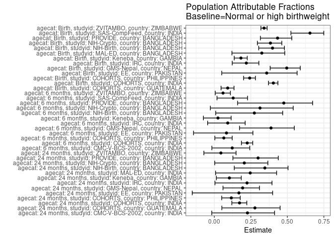

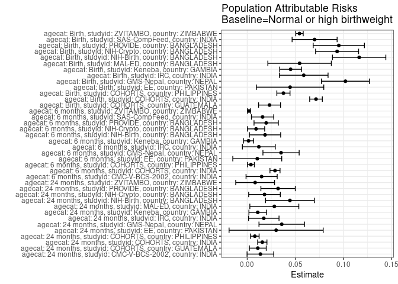

## Results Table

### Parameter: TSM

| agecat | studyid | country | intervention_level | baseline_level | estimate | ci_lower | ci_upper |
| --- | --- | --- | --- | --- | --- | --- | --- |
| Birth | COHORTS | GUATEMALA | Normal or high birthweight | NA | 0.2307692 | 0.1995815 | 0.2619570 |
| Birth | COHORTS | GUATEMALA | Low birthweight | NA | 0.5555556 | 0.4229349 | 0.6881762 |
| Birth | COHORTS | INDIA | Normal or high birthweight | NA | 0.1054461 | 0.0970801 | 0.1138122 |
| Birth | COHORTS | INDIA | Low birthweight | NA | 0.5418719 | 0.5112176 | 0.5725263 |
| Birth | COHORTS | PHILIPPINES | Normal or high birthweight | NA | 0.1179315 | 0.1057368 | 0.1301263 |
| Birth | COHORTS | PHILIPPINES | Low birthweight | NA | 0.6350711 | 0.5701035 | 0.7000387 |
| Birth | EE | PAKISTAN | Normal or high birthweight | NA | 0.0797101 | 0.0343935 | 0.1250268 |
| Birth | EE | PAKISTAN | Low birthweight | NA | 0.2820513 | 0.1404208 | 0.4236818 |
| Birth | GMS-Nepal | NEPAL | Normal or high birthweight | NA | 0.1038136 | 0.0762749 | 0.1313522 |
| Birth | GMS-Nepal | NEPAL | Low birthweight | NA | 0.4911243 | 0.4156940 | 0.5665545 |
| Birth | IRC | INDIA | Normal or high birthweight | NA | 0.2094595 | 0.1630348 | 0.2558841 |
| Birth | IRC | INDIA | Low birthweight | NA | 0.6382979 | 0.5007289 | 0.7758668 |
| Birth | Keneba | GAMBIA | Normal or high birthweight | NA | 0.2026709 | 0.1805808 | 0.2247609 |
| Birth | Keneba | GAMBIA | Low birthweight | NA | 0.5468750 | 0.4764383 | 0.6173117 |
| Birth | MAL-ED | BANGLADESH | Normal or high birthweight | NA | 0.1129944 | 0.0662461 | 0.1597426 |
| Birth | MAL-ED | BANGLADESH | Low birthweight | NA | 0.4210526 | 0.2637064 | 0.5783989 |
| Birth | NIH-Birth | BANGLADESH | Normal or high birthweight | NA | 0.1757720 | 0.1393818 | 0.2121621 |
| Birth | NIH-Birth | BANGLADESH | Low birthweight | NA | 0.6103896 | 0.5333020 | 0.6874772 |
| Birth | NIH-Crypto | BANGLADESH | Normal or high birthweight | NA | 0.1498195 | 0.1200795 | 0.1795594 |
| Birth | NIH-Crypto | BANGLADESH | Low birthweight | NA | 0.5816993 | 0.5034820 | 0.6599167 |
| Birth | PROVIDE | BANGLADESH | Normal or high birthweight | NA | 0.1246883 | 0.0923231 | 0.1570535 |
| Birth | PROVIDE | BANGLADESH | Low birthweight | NA | 0.5114504 | 0.4257708 | 0.5971299 |
| Birth | SAS-CompFeed | INDIA | Normal or high birthweight | NA | 0.0369128 | 0.0209631 | 0.0528624 |
| Birth | SAS-CompFeed | INDIA | Low birthweight | NA | 0.4066986 | 0.3301184 | 0.4832788 |
| Birth | ZVITAMBO | ZIMBABWE | Normal or high birthweight | NA | 0.1052178 | 0.0996373 | 0.1107984 |
| Birth | ZVITAMBO | ZIMBABWE | Low birthweight | NA | 0.6438987 | 0.6178978 | 0.6698996 |
| 6 months | CMC-V-BCS-2002 | INDIA | Normal or high birthweight | NA | 0.1072555 | 0.0731444 | 0.1413666 |
| 6 months | CMC-V-BCS-2002 | INDIA | Low birthweight | NA | 0.2325581 | 0.1061118 | 0.3590045 |
| 6 months | COHORTS | INDIA | Normal or high birthweight | NA | 0.0994000 | 0.0911061 | 0.1076939 |
| 6 months | COHORTS | INDIA | Low birthweight | NA | 0.2436102 | 0.2198308 | 0.2673896 |
| 6 months | COHORTS | PHILIPPINES | Normal or high birthweight | NA | 0.0554636 | 0.0463352 | 0.0645920 |
| 6 months | COHORTS | PHILIPPINES | Low birthweight | NA | 0.0967742 | 0.0599713 | 0.1335771 |
| 6 months | EE | PAKISTAN | Normal or high birthweight | NA | 0.1152263 | 0.0750271 | 0.1554256 |
| 6 months | EE | PAKISTAN | Low birthweight | NA | 0.1450382 | 0.0846560 | 0.2054203 |
| 6 months | GMS-Nepal | NEPAL | Normal or high birthweight | NA | 0.0554156 | 0.0328901 | 0.0779412 |
| 6 months | GMS-Nepal | NEPAL | Low birthweight | NA | 0.1746988 | 0.1168850 | 0.2325126 |
| 6 months | IRC | INDIA | Normal or high birthweight | NA | 0.1197605 | 0.0848968 | 0.1546241 |
| 6 months | IRC | INDIA | Low birthweight | NA | 0.1911765 | 0.0975974 | 0.2847555 |
| 6 months | Keneba | GAMBIA | Normal or high birthweight | NA | 0.0541012 | 0.0409990 | 0.0672034 |
| 6 months | Keneba | GAMBIA | Low birthweight | NA | 0.0638298 | 0.0288738 | 0.0987857 |
| 6 months | NIH-Birth | BANGLADESH | Normal or high birthweight | NA | 0.0490463 | 0.0269298 | 0.0711629 |
| 6 months | NIH-Birth | BANGLADESH | Low birthweight | NA | 0.1125828 | 0.0621191 | 0.1630465 |
| 6 months | NIH-Crypto | BANGLADESH | Normal or high birthweight | NA | 0.0201835 | 0.0083687 | 0.0319982 |
| 6 months | NIH-Crypto | BANGLADESH | Low birthweight | NA | 0.0588235 | 0.0234288 | 0.0942183 |
| 6 months | PROVIDE | BANGLADESH | Normal or high birthweight | NA | 0.0217391 | 0.0084015 | 0.0350767 |
| 6 months | PROVIDE | BANGLADESH | Low birthweight | NA | 0.1048951 | 0.0546313 | 0.1551589 |
| 6 months | SAS-CompFeed | INDIA | Normal or high birthweight | NA | 0.1078921 | 0.0775356 | 0.1382486 |
| 6 months | SAS-CompFeed | INDIA | Low birthweight | NA | 0.1733746 | 0.1394939 | 0.2072554 |
| 6 months | ZVITAMBO | ZIMBABWE | Normal or high birthweight | NA | 0.0293045 | 0.0254629 | 0.0331462 |
| 6 months | ZVITAMBO | ZIMBABWE | Low birthweight | NA | 0.0440075 | 0.0317054 | 0.0563096 |
| 24 months | CMC-V-BCS-2002 | INDIA | Normal or high birthweight | NA | 0.0467290 | 0.0236086 | 0.0698493 |
| 24 months | CMC-V-BCS-2002 | INDIA | Low birthweight | NA | 0.1627907 | 0.0522956 | 0.2732858 |
| 24 months | COHORTS | GUATEMALA | Normal or high birthweight | NA | 0.0285714 | 0.0151749 | 0.0419679 |
| 24 months | COHORTS | GUATEMALA | Low birthweight | NA | 0.1451613 | 0.0574106 | 0.2329120 |
| 24 months | COHORTS | INDIA | Normal or high birthweight | NA | 0.0751726 | 0.0669082 | 0.0834370 |
| 24 months | COHORTS | INDIA | Low birthweight | NA | 0.1582418 | 0.1345266 | 0.1819570 |
| 24 months | COHORTS | PHILIPPINES | Normal or high birthweight | NA | 0.0601367 | 0.0501890 | 0.0700844 |
| 24 months | COHORTS | PHILIPPINES | Low birthweight | NA | 0.1488372 | 0.1012510 | 0.1964234 |
| 24 months | EE | PAKISTAN | Normal or high birthweight | NA | 0.1485149 | 0.0789552 | 0.2180745 |
| 24 months | EE | PAKISTAN | Low birthweight | NA | 0.2238806 | 0.1237701 | 0.3239911 |
| 24 months | GMS-Nepal | NEPAL | Normal or high birthweight | NA | 0.1492958 | 0.1121855 | 0.1864061 |
| 24 months | GMS-Nepal | NEPAL | Low birthweight | NA | 0.2824427 | 0.2052719 | 0.3596136 |
| 24 months | IRC | INDIA | Normal or high birthweight | NA | 0.0597015 | 0.0342982 | 0.0851048 |
| 24 months | IRC | INDIA | Low birthweight | NA | 0.1617647 | 0.0741337 | 0.2493958 |
| 24 months | Keneba | GAMBIA | Normal or high birthweight | NA | 0.0950276 | 0.0759127 | 0.1141425 |
| 24 months | Keneba | GAMBIA | Low birthweight | NA | 0.1710526 | 0.1111618 | 0.2309434 |
| 24 months | MAL-ED | INDIA | Normal or high birthweight | NA | 0.0864865 | 0.0458896 | 0.1270833 |
| 24 months | MAL-ED | INDIA | Low birthweight | NA | 0.2727273 | 0.1204264 | 0.4250282 |
| 24 months | NIH-Birth | BANGLADESH | Normal or high birthweight | NA | 0.0839161 | 0.0517438 | 0.1160884 |
| 24 months | NIH-Birth | BANGLADESH | Low birthweight | NA | 0.2283465 | 0.1552526 | 0.3014403 |
| 24 months | NIH-Crypto | BANGLADESH | Normal or high birthweight | NA | 0.0695876 | 0.0442446 | 0.0949307 |
| 24 months | NIH-Crypto | BANGLADESH | Low birthweight | NA | 0.1428571 | 0.0816977 | 0.2040166 |
| 24 months | PROVIDE | BANGLADESH | Normal or high birthweight | NA | 0.0750000 | 0.0503681 | 0.0996319 |
| 24 months | PROVIDE | BANGLADESH | Low birthweight | NA | 0.2086331 | 0.1410253 | 0.2762409 |
| 24 months | ZVITAMBO | ZIMBABWE | Normal or high birthweight | NA | 0.1750742 | 0.1344527 | 0.2156957 |
| 24 months | ZVITAMBO | ZIMBABWE | Low birthweight | NA | 0.2127660 | 0.1299352 | 0.2955967 |

### Parameter: E(Y)

| agecat | studyid | country | intervention_level | baseline_level | estimate | ci_lower | ci_upper |
| --- | --- | --- | --- | --- | --- | --- | --- |
| Birth | COHORTS | GUATEMALA | NA | NA | 0.2539683 | 0.2229196 | 0.2850169 |
| Birth | COHORTS | INDIA | NA | NA | 0.1769740 | 0.1674681 | 0.1864799 |
| Birth | COHORTS | PHILIPPINES | NA | NA | 0.1555709 | 0.1423748 | 0.1687670 |
| Birth | EE | PAKISTAN | NA | NA | 0.1242938 | 0.0755526 | 0.1730349 |
| Birth | GMS-Nepal | NEPAL | NA | NA | 0.2059282 | 0.1745993 | 0.2372572 |
| Birth | IRC | INDIA | NA | NA | 0.2682216 | 0.2212677 | 0.3151755 |
| Birth | Keneba | GAMBIA | NA | NA | 0.2477816 | 0.2256667 | 0.2698964 |
| Birth | MAL-ED | BANGLADESH | NA | NA | 0.1674419 | 0.1174176 | 0.2174661 |
| Birth | NIH-Birth | BANGLADESH | NA | NA | 0.2921739 | 0.2549711 | 0.3293768 |
| Birth | NIH-Crypto | BANGLADESH | NA | NA | 0.2432815 | 0.2116319 | 0.2749310 |
| Birth | PROVIDE | BANGLADESH | NA | NA | 0.2199248 | 0.1846953 | 0.2551543 |
| Birth | SAS-CompFeed | INDIA | NA | NA | 0.1069810 | 0.0760961 | 0.1378659 |
| Birth | ZVITAMBO | ZIMBABWE | NA | NA | 0.1595572 | 0.1532418 | 0.1658725 |
| 6 months | CMC-V-BCS-2002 | INDIA | NA | NA | 0.1222222 | 0.0883403 | 0.1561042 |
| 6 months | COHORTS | INDIA | NA | NA | 0.1282790 | 0.1199892 | 0.1365687 |
| 6 months | COHORTS | PHILIPPINES | NA | NA | 0.0593093 | 0.0503382 | 0.0682804 |
| 6 months | EE | PAKISTAN | NA | NA | 0.1256684 | 0.0920293 | 0.1593076 |
| 6 months | GMS-Nepal | NEPAL | NA | NA | 0.0905861 | 0.0668565 | 0.1143158 |
| 6 months | IRC | INDIA | NA | NA | 0.1318408 | 0.0987276 | 0.1649539 |
| 6 months | Keneba | GAMBIA | NA | NA | 0.0554723 | 0.0431843 | 0.0677602 |
| 6 months | NIH-Birth | BANGLADESH | NA | NA | 0.0675676 | 0.0459314 | 0.0892038 |
| 6 months | NIH-Crypto | BANGLADESH | NA | NA | 0.0293706 | 0.0169860 | 0.0417552 |
| 6 months | PROVIDE | BANGLADESH | NA | NA | 0.0414594 | 0.0255348 | 0.0573839 |
| 6 months | SAS-CompFeed | INDIA | NA | NA | 0.1238671 | 0.0990601 | 0.1486741 |
| 6 months | ZVITAMBO | ZIMBABWE | NA | NA | 0.0311578 | 0.0274581 | 0.0348575 |
| 24 months | CMC-V-BCS-2002 | INDIA | NA | NA | 0.0604396 | 0.0359254 | 0.0849538 |
| 24 months | COHORTS | GUATEMALA | NA | NA | 0.0395738 | 0.0246551 | 0.0544926 |
| 24 months | COHORTS | INDIA | NA | NA | 0.0908525 | 0.0827390 | 0.0989661 |
| 24 months | COHORTS | PHILIPPINES | NA | NA | 0.0680498 | 0.0579935 | 0.0781061 |
| 24 months | EE | PAKISTAN | NA | NA | 0.1785714 | 0.1204842 | 0.2366587 |
| 24 months | GMS-Nepal | NEPAL | NA | NA | 0.1851852 | 0.1506144 | 0.2197560 |
| 24 months | IRC | INDIA | NA | NA | 0.0769231 | 0.0508746 | 0.1029716 |
| 24 months | Keneba | GAMBIA | NA | NA | 0.1059603 | 0.0873965 | 0.1245240 |
| 24 months | MAL-ED | INDIA | NA | NA | 0.1146789 | 0.0722843 | 0.1570735 |
| 24 months | NIH-Birth | BANGLADESH | NA | NA | 0.1283293 | 0.0960341 | 0.1606245 |
| 24 months | NIH-Crypto | BANGLADESH | NA | NA | 0.0875486 | 0.0630907 | 0.1120065 |
| 24 months | PROVIDE | BANGLADESH | NA | NA | 0.1070812 | 0.0818727 | 0.1322897 |
| 24 months | ZVITAMBO | ZIMBABWE | NA | NA | 0.1832947 | 0.1467250 | 0.2198644 |

### Parameter: RR

| agecat | studyid | country | intervention_level | baseline_level | estimate | ci_lower | ci_upper |
| --- | --- | --- | --- | --- | --- | --- | --- |
| Birth | COHORTS | GUATEMALA | Normal or high birthweight | Normal or high birthweight | 1.000000 | 1.0000000 | 1.000000 |
| Birth | COHORTS | GUATEMALA | Low birthweight | Normal or high birthweight | 2.407407 | 1.8298464 | 3.167266 |
| Birth | COHORTS | INDIA | Normal or high birthweight | Normal or high birthweight | 1.000000 | 1.0000000 | 1.000000 |
| Birth | COHORTS | INDIA | Low birthweight | Normal or high birthweight | 5.138851 | 4.6617313 | 5.664804 |
| Birth | COHORTS | PHILIPPINES | Normal or high birthweight | Normal or high birthweight | 1.000000 | 1.0000000 | 1.000000 |
| Birth | COHORTS | PHILIPPINES | Low birthweight | Normal or high birthweight | 5.385082 | 4.6560839 | 6.228219 |
| Birth | EE | PAKISTAN | Normal or high birthweight | Normal or high birthweight | 1.000000 | 1.0000000 | 1.000000 |
| Birth | EE | PAKISTAN | Low birthweight | Normal or high birthweight | 3.538461 | 1.6572602 | 7.555066 |
| Birth | GMS-Nepal | NEPAL | Normal or high birthweight | Normal or high birthweight | 1.000000 | 1.0000000 | 1.000000 |
| Birth | GMS-Nepal | NEPAL | Low birthweight | Normal or high birthweight | 4.730830 | 3.4818937 | 6.427752 |
| Birth | IRC | INDIA | Normal or high birthweight | Normal or high birthweight | 1.000000 | 1.0000000 | 1.000000 |
| Birth | IRC | INDIA | Low birthweight | Normal or high birthweight | 3.047358 | 2.2369704 | 4.151324 |
| Birth | Keneba | GAMBIA | Normal or high birthweight | Normal or high birthweight | 1.000000 | 1.0000000 | 1.000000 |
| Birth | Keneba | GAMBIA | Low birthweight | Normal or high birthweight | 2.698341 | 2.2793942 | 3.194288 |
| Birth | MAL-ED | BANGLADESH | Normal or high birthweight | Normal or high birthweight | 1.000000 | 1.0000000 | 1.000000 |
| Birth | MAL-ED | BANGLADESH | Low birthweight | Normal or high birthweight | 3.726316 | 2.1338154 | 6.507325 |
| Birth | NIH-Birth | BANGLADESH | Normal or high birthweight | Normal or high birthweight | 1.000000 | 1.0000000 | 1.000000 |
| Birth | NIH-Birth | BANGLADESH | Low birthweight | Normal or high birthweight | 3.472622 | 2.7248121 | 4.425664 |
| Birth | NIH-Crypto | BANGLADESH | Normal or high birthweight | Normal or high birthweight | 1.000000 | 1.0000000 | 1.000000 |
| Birth | NIH-Crypto | BANGLADESH | Low birthweight | Normal or high birthweight | 3.882668 | 3.0549483 | 4.934653 |
| Birth | PROVIDE | BANGLADESH | Normal or high birthweight | Normal or high birthweight | 1.000000 | 1.0000000 | 1.000000 |
| Birth | PROVIDE | BANGLADESH | Low birthweight | Normal or high birthweight | 4.101832 | 3.0116862 | 5.586580 |
| Birth | SAS-CompFeed | INDIA | Normal or high birthweight | Normal or high birthweight | 1.000000 | 1.0000000 | 1.000000 |
| Birth | SAS-CompFeed | INDIA | Low birthweight | Normal or high birthweight | 11.017834 | 6.7856467 | 17.889623 |
| Birth | ZVITAMBO | ZIMBABWE | Normal or high birthweight | Normal or high birthweight | 1.000000 | 1.0000000 | 1.000000 |
| Birth | ZVITAMBO | ZIMBABWE | Low birthweight | Normal or high birthweight | 6.119672 | 5.7250316 | 6.541516 |
| 6 months | CMC-V-BCS-2002 | INDIA | Normal or high birthweight | Normal or high birthweight | 1.000000 | 1.0000000 | 1.000000 |
| 6 months | CMC-V-BCS-2002 | INDIA | Low birthweight | Normal or high birthweight | 2.168263 | 1.1549110 | 4.070758 |
| 6 months | COHORTS | INDIA | Normal or high birthweight | Normal or high birthweight | 1.000000 | 1.0000000 | 1.000000 |
| 6 months | COHORTS | INDIA | Low birthweight | Normal or high birthweight | 2.450807 | 2.1554569 | 2.786627 |
| 6 months | COHORTS | PHILIPPINES | Normal or high birthweight | Normal or high birthweight | 1.000000 | 1.0000000 | 1.000000 |
| 6 months | COHORTS | PHILIPPINES | Low birthweight | Normal or high birthweight | 1.744824 | 1.1528891 | 2.640680 |
| 6 months | EE | PAKISTAN | Normal or high birthweight | Normal or high birthweight | 1.000000 | 1.0000000 | 1.000000 |
| 6 months | EE | PAKISTAN | Low birthweight | Normal or high birthweight | 1.258724 | 0.7311979 | 2.166836 |
| 6 months | GMS-Nepal | NEPAL | Normal or high birthweight | Normal or high birthweight | 1.000000 | 1.0000000 | 1.000000 |
| 6 months | GMS-Nepal | NEPAL | Low birthweight | Normal or high birthweight | 3.152519 | 1.8664521 | 5.324743 |
| 6 months | IRC | INDIA | Normal or high birthweight | Normal or high birthweight | 1.000000 | 1.0000000 | 1.000000 |
| 6 months | IRC | INDIA | Low birthweight | Normal or high birthweight | 1.596324 | 0.9032000 | 2.821356 |
| 6 months | Keneba | GAMBIA | Normal or high birthweight | Normal or high birthweight | 1.000000 | 1.0000000 | 1.000000 |
| 6 months | Keneba | GAMBIA | Low birthweight | Normal or high birthweight | 1.179822 | 0.6482759 | 2.147201 |
| 6 months | NIH-Birth | BANGLADESH | Normal or high birthweight | Normal or high birthweight | 1.000000 | 1.0000000 | 1.000000 |
| 6 months | NIH-Birth | BANGLADESH | Low birthweight | Normal or high birthweight | 2.295438 | 1.2154478 | 4.335056 |
| 6 months | NIH-Crypto | BANGLADESH | Normal or high birthweight | Normal or high birthweight | 1.000000 | 1.0000000 | 1.000000 |
| 6 months | NIH-Crypto | BANGLADESH | Low birthweight | Normal or high birthweight | 2.914439 | 1.2588610 | 6.747331 |
| 6 months | PROVIDE | BANGLADESH | Normal or high birthweight | Normal or high birthweight | 1.000000 | 1.0000000 | 1.000000 |
| 6 months | PROVIDE | BANGLADESH | Low birthweight | Normal or high birthweight | 4.825175 | 2.2152499 | 10.510016 |
| 6 months | SAS-CompFeed | INDIA | Normal or high birthweight | Normal or high birthweight | 1.000000 | 1.0000000 | 1.000000 |
| 6 months | SAS-CompFeed | INDIA | Low birthweight | Normal or high birthweight | 1.606926 | 1.1584453 | 2.229031 |
| 6 months | ZVITAMBO | ZIMBABWE | Normal or high birthweight | Normal or high birthweight | 1.000000 | 1.0000000 | 1.000000 |
| 6 months | ZVITAMBO | ZIMBABWE | Low birthweight | Normal or high birthweight | 1.501730 | 1.1028086 | 2.044955 |
| 24 months | CMC-V-BCS-2002 | INDIA | Normal or high birthweight | Normal or high birthweight | 1.000000 | 1.0000000 | 1.000000 |
| 24 months | CMC-V-BCS-2002 | INDIA | Low birthweight | Normal or high birthweight | 3.483721 | 1.5040379 | 8.069153 |
| 24 months | COHORTS | GUATEMALA | Normal or high birthweight | Normal or high birthweight | 1.000000 | 1.0000000 | 1.000000 |
| 24 months | COHORTS | GUATEMALA | Low birthweight | Normal or high birthweight | 5.080645 | 2.3641232 | 10.918617 |
| 24 months | COHORTS | INDIA | Normal or high birthweight | Normal or high birthweight | 1.000000 | 1.0000000 | 1.000000 |
| 24 months | COHORTS | INDIA | Low birthweight | Normal or high birthweight | 2.105046 | 1.7479965 | 2.535027 |
| 24 months | COHORTS | PHILIPPINES | Normal or high birthweight | Normal or high birthweight | 1.000000 | 1.0000000 | 1.000000 |
| 24 months | COHORTS | PHILIPPINES | Low birthweight | Normal or high birthweight | 2.474982 | 1.7267751 | 3.547386 |
| 24 months | EE | PAKISTAN | Normal or high birthweight | Normal or high birthweight | 1.000000 | 1.0000000 | 1.000000 |
| 24 months | EE | PAKISTAN | Low birthweight | Normal or high birthweight | 1.507463 | 0.7888949 | 2.880540 |
| 24 months | GMS-Nepal | NEPAL | Normal or high birthweight | Normal or high birthweight | 1.000000 | 1.0000000 | 1.000000 |
| 24 months | GMS-Nepal | NEPAL | Low birthweight | Normal or high birthweight | 1.891833 | 1.3075690 | 2.737166 |
| 24 months | IRC | INDIA | Normal or high birthweight | Normal or high birthweight | 1.000000 | 1.0000000 | 1.000000 |
| 24 months | IRC | INDIA | Low birthweight | Normal or high birthweight | 2.709559 | 1.3606132 | 5.395883 |
| 24 months | Keneba | GAMBIA | Normal or high birthweight | Normal or high birthweight | 1.000000 | 1.0000000 | 1.000000 |
| 24 months | Keneba | GAMBIA | Low birthweight | Normal or high birthweight | 1.800031 | 1.2020219 | 2.695550 |
| 24 months | MAL-ED | INDIA | Normal or high birthweight | Normal or high birthweight | 1.000000 | 1.0000000 | 1.000000 |
| 24 months | MAL-ED | INDIA | Low birthweight | Normal or high birthweight | 3.153409 | 1.5203970 | 6.540390 |
| 24 months | NIH-Birth | BANGLADESH | Normal or high birthweight | Normal or high birthweight | 1.000000 | 1.0000000 | 1.000000 |
| 24 months | NIH-Birth | BANGLADESH | Low birthweight | Normal or high birthweight | 2.721129 | 1.6513573 | 4.483912 |
| 24 months | NIH-Crypto | BANGLADESH | Normal or high birthweight | Normal or high birthweight | 1.000000 | 1.0000000 | 1.000000 |
| 24 months | NIH-Crypto | BANGLADESH | Low birthweight | Normal or high birthweight | 2.052910 | 1.1702221 | 3.601402 |
| 24 months | PROVIDE | BANGLADESH | Normal or high birthweight | Normal or high birthweight | 1.000000 | 1.0000000 | 1.000000 |
| 24 months | PROVIDE | BANGLADESH | Low birthweight | Normal or high birthweight | 2.781775 | 1.7536650 | 4.412627 |
| 24 months | ZVITAMBO | ZIMBABWE | Normal or high birthweight | Normal or high birthweight | 1.000000 | 1.0000000 | 1.000000 |
| 24 months | ZVITAMBO | ZIMBABWE | Low birthweight | Normal or high birthweight | 1.215290 | 0.7724249 | 1.912070 |

### Parameter: PAR

| agecat | studyid | country | intervention_level | baseline_level | estimate | ci_lower | ci_upper |
| --- | --- | --- | --- | --- | --- | --- | --- |
| Birth | COHORTS | GUATEMALA | Normal or high birthweight | NA | 0.0231990 | 0.0117842 | 0.0346138 |
| Birth | COHORTS | INDIA | Normal or high birthweight | NA | 0.0715279 | 0.0649466 | 0.0781092 |
| Birth | COHORTS | PHILIPPINES | Normal or high birthweight | NA | 0.0376393 | 0.0307785 | 0.0445002 |
| Birth | EE | PAKISTAN | Normal or high birthweight | NA | 0.0445836 | 0.0095540 | 0.0796133 |
| Birth | GMS-Nepal | NEPAL | Normal or high birthweight | NA | 0.1021147 | 0.0771543 | 0.1270750 |
| Birth | IRC | INDIA | Normal or high birthweight | NA | 0.0587621 | 0.0334624 | 0.0840618 |
| Birth | Keneba | GAMBIA | Normal or high birthweight | NA | 0.0451107 | 0.0337528 | 0.0564686 |
| Birth | MAL-ED | BANGLADESH | Normal or high birthweight | NA | 0.0544475 | 0.0214393 | 0.0874557 |
| Birth | NIH-Birth | BANGLADESH | Normal or high birthweight | NA | 0.1164019 | 0.0886685 | 0.1441354 |
| Birth | NIH-Crypto | BANGLADESH | Normal or high birthweight | NA | 0.0934620 | 0.0711004 | 0.1158235 |
| Birth | PROVIDE | BANGLADESH | Normal or high birthweight | NA | 0.0952365 | 0.0686004 | 0.1218727 |
| Birth | SAS-CompFeed | INDIA | Normal or high birthweight | NA | 0.0700682 | 0.0466612 | 0.0934752 |
| Birth | ZVITAMBO | ZIMBABWE | Normal or high birthweight | NA | 0.0543393 | 0.0504633 | 0.0582154 |
| 6 months | CMC-V-BCS-2002 | INDIA | Normal or high birthweight | NA | 0.0149667 | -0.0012315 | 0.0311649 |
| 6 months | COHORTS | INDIA | Normal or high birthweight | NA | 0.0288790 | 0.0236366 | 0.0341213 |
| 6 months | COHORTS | PHILIPPINES | Normal or high birthweight | NA | 0.0038457 | 0.0002865 | 0.0074050 |
| 6 months | EE | PAKISTAN | Normal or high birthweight | NA | 0.0104421 | -0.0150071 | 0.0358913 |
| 6 months | GMS-Nepal | NEPAL | Normal or high birthweight | NA | 0.0351705 | 0.0163315 | 0.0540096 |
| 6 months | IRC | INDIA | Normal or high birthweight | NA | 0.0120803 | -0.0050139 | 0.0291745 |
| 6 months | Keneba | GAMBIA | Normal or high birthweight | NA | 0.0013710 | -0.0038931 | 0.0066352 |
| 6 months | NIH-Birth | BANGLADESH | Normal or high birthweight | NA | 0.0185212 | 0.0022683 | 0.0347742 |
| 6 months | NIH-Crypto | BANGLADESH | Normal or high birthweight | NA | 0.0091871 | 0.0002335 | 0.0181408 |
| 6 months | PROVIDE | BANGLADESH | Normal or high birthweight | NA | 0.0197202 | 0.0070683 | 0.0323722 |
| 6 months | SAS-CompFeed | INDIA | Normal or high birthweight | NA | 0.0159750 | 0.0043707 | 0.0275793 |
| 6 months | ZVITAMBO | ZIMBABWE | Normal or high birthweight | NA | 0.0018533 | 0.0002255 | 0.0034811 |
| 24 months | CMC-V-BCS-2002 | INDIA | Normal or high birthweight | NA | 0.0137106 | -0.0001707 | 0.0275919 |
| 24 months | COHORTS | GUATEMALA | Normal or high birthweight | NA | 0.0110024 | 0.0022289 | 0.0197759 |
| 24 months | COHORTS | INDIA | Normal or high birthweight | NA | 0.0156799 | 0.0108515 | 0.0205084 |
| 24 months | COHORTS | PHILIPPINES | Normal or high birthweight | NA | 0.0079131 | 0.0034601 | 0.0123661 |
| 24 months | EE | PAKISTAN | Normal or high birthweight | NA | 0.0300566 | -0.0188811 | 0.0789943 |
| 24 months | GMS-Nepal | NEPAL | Normal or high birthweight | NA | 0.0358894 | 0.0122167 | 0.0595621 |
| 24 months | IRC | INDIA | Normal or high birthweight | NA | 0.0172216 | 0.0013795 | 0.0330637 |
| 24 months | Keneba | GAMBIA | Normal or high birthweight | NA | 0.0109326 | 0.0017501 | 0.0201152 |
| 24 months | MAL-ED | INDIA | Normal or high birthweight | NA | 0.0281924 | 0.0027333 | 0.0536515 |
| 24 months | NIH-Birth | BANGLADESH | Normal or high birthweight | NA | 0.0444132 | 0.0190262 | 0.0698002 |
| 24 months | NIH-Crypto | BANGLADESH | Normal or high birthweight | NA | 0.0179610 | 0.0015048 | 0.0344172 |
| 24 months | PROVIDE | BANGLADESH | Normal or high birthweight | NA | 0.0320812 | 0.0141912 | 0.0499711 |
| 24 months | ZVITAMBO | ZIMBABWE | Normal or high birthweight | NA | 0.0082205 | -0.0119539 | 0.0283948 |

### Parameter: PAF

| agecat | studyid | country | intervention_level | baseline_level | estimate | ci_lower | ci_upper |
| --- | --- | --- | --- | --- | --- | --- | --- |
| Birth | COHORTS | GUATEMALA | Normal or high birthweight | NA | 0.0913462 | 0.0458294 | 0.1346917 |
| Birth | COHORTS | INDIA | Normal or high birthweight | NA | 0.4041717 | 0.3711583 | 0.4354520 |
| Birth | COHORTS | PHILIPPINES | Normal or high birthweight | NA | 0.2419433 | 0.2003274 | 0.2813935 |
| Birth | EE | PAKISTAN | Normal or high birthweight | NA | 0.3586957 | 0.0507722 | 0.5667307 |
| Birth | GMS-Nepal | NEPAL | Normal or high birthweight | NA | 0.4958751 | 0.3823172 | 0.5885559 |
| Birth | IRC | INDIA | Normal or high birthweight | NA | 0.2190805 | 0.1226456 | 0.3049157 |
| Birth | Keneba | GAMBIA | Normal or high birthweight | NA | 0.1820584 | 0.1363358 | 0.2253604 |
| Birth | MAL-ED | BANGLADESH | Normal or high birthweight | NA | 0.3251726 | 0.1203898 | 0.4822798 |
| Birth | NIH-Birth | BANGLADESH | Normal or high birthweight | NA | 0.3983995 | 0.3038307 | 0.4801219 |
| Birth | NIH-Crypto | BANGLADESH | Normal or high birthweight | NA | 0.3841722 | 0.2949691 | 0.4620890 |
| Birth | PROVIDE | BANGLADESH | Normal or high birthweight | NA | 0.4330413 | 0.3155823 | 0.5303422 |
| Birth | SAS-CompFeed | INDIA | Normal or high birthweight | NA | 0.6549596 | 0.5245258 | 0.7496124 |
| Birth | ZVITAMBO | ZIMBABWE | Normal or high birthweight | NA | 0.3405634 | 0.3189099 | 0.3615284 |
| 6 months | CMC-V-BCS-2002 | INDIA | Normal or high birthweight | NA | 0.1224548 | -0.0167450 | 0.2425972 |
| 6 months | COHORTS | INDIA | Normal or high birthweight | NA | 0.2251262 | 0.1853215 | 0.2629860 |
| 6 months | COHORTS | PHILIPPINES | Normal or high birthweight | NA | 0.0648420 | 0.0036214 | 0.1223010 |
| 6 months | EE | PAKISTAN | Normal or high birthweight | NA | 0.0830925 | -0.1423992 | 0.2640758 |
| 6 months | GMS-Nepal | NEPAL | Normal or high birthweight | NA | 0.3882551 | 0.1724461 | 0.5477855 |
| 6 months | IRC | INDIA | Normal or high birthweight | NA | 0.0916281 | -0.0460255 | 0.2111669 |
| 6 months | Keneba | GAMBIA | Normal or high birthweight | NA | 0.0247158 | -0.0747971 | 0.1150151 |
| 6 months | NIH-Birth | BANGLADESH | Normal or high birthweight | NA | 0.2741144 | 0.0093076 | 0.4681398 |
| 6 months | NIH-Crypto | BANGLADESH | Normal or high birthweight | NA | 0.3128003 | -0.0270827 | 0.5402090 |
| 6 months | PROVIDE | BANGLADESH | Normal or high birthweight | NA | 0.4756522 | 0.1593382 | 0.6729474 |
| 6 months | SAS-CompFeed | INDIA | Normal or high birthweight | NA | 0.1289686 | 0.0181318 | 0.2272937 |
| 6 months | ZVITAMBO | ZIMBABWE | Normal or high birthweight | NA | 0.0594802 | 0.0062337 | 0.1098737 |
| 24 months | CMC-V-BCS-2002 | INDIA | Normal or high birthweight | NA | 0.2268479 | -0.0176306 | 0.4125922 |
| 24 months | COHORTS | GUATEMALA | Normal or high birthweight | NA | 0.2780220 | 0.0514908 | 0.4504510 |
| 24 months | COHORTS | INDIA | Normal or high birthweight | NA | 0.1725866 | 0.1197195 | 0.2222787 |
| 24 months | COHORTS | PHILIPPINES | Normal or high birthweight | NA | 0.1162842 | 0.0505100 | 0.1775021 |
| 24 months | EE | PAKISTAN | Normal or high birthweight | NA | 0.1683168 | -0.1514072 | 0.3992595 |
| 24 months | GMS-Nepal | NEPAL | Normal or high birthweight | NA | 0.1938028 | 0.0591207 | 0.3092059 |
| 24 months | IRC | INDIA | Normal or high birthweight | NA | 0.2238806 | 0.0042292 | 0.3950804 |
| 24 months | Keneba | GAMBIA | Normal or high birthweight | NA | 0.1031768 | 0.0138390 | 0.1844213 |
| 24 months | MAL-ED | INDIA | Normal or high birthweight | NA | 0.2458378 | 0.0083077 | 0.4264748 |
| 24 months | NIH-Birth | BANGLADESH | Normal or high birthweight | NA | 0.3460879 | 0.1366503 | 0.5047186 |
| 24 months | NIH-Crypto | BANGLADESH | Normal or high birthweight | NA | 0.2051546 | 0.0026302 | 0.3665548 |
| 24 months | PROVIDE | BANGLADESH | Normal or high birthweight | NA | 0.2995968 | 0.1271226 | 0.4379913 |
| 24 months | ZVITAMBO | ZIMBABWE | Normal or high birthweight | NA | 0.0448484 | -0.0715757 | 0.1486234 |